# Compare Gestures III.1: February 2020 pilot data

# Comparing Gestures

# Get all the filenames of the gestures

```
The working directory was changed to /Users/xx/Github/GepetoR/data/21_02-study/all_gestures inside a notebook chunk. The working directory will be reset when the chunk is finished running. Use the knitr root.dir option in the setup chunk to change the working directory for notebook chunks.
```

# Extract the reference phrase from the whole gesture name

get_ref_name <- function(gest_name) { return(str_split(gest_name, ‘-’)[[1]][3]) }

# Finds the number of samples in the reference for the particular gesture

get_num_samples <-function(gest_name) { # Find how many samples are in the ref file ref_phrase <- get_ref_name(gest_name)  
return(length(get_ref_timestamps(ref_phrase))) }

# Load gest data and convert time

prep_gest<-function(gest) { # Convert time to percentage max_time <- tail(gest$t_end, 1) gest <- gest %>% mutate(percent=t_init/max_time) %>% # only keep local scrub time and the freq values select(percent, f, scrub) return(gest) }

# args: data - tibble with columns: percent (% of way through signal) & f (frequency at that point),

# num_samples - # equally spaced points in outpt

# returns: tibble with coluumns index & value. index has num_samples equally spaced points from 0 to 1

# values are interplolated from f

get_interpolated_data <- function(data, num_samples) { # Add end points at 0 and 1 if they don’t already exist, duplicating first and last available f value if (! 0 %in% data$percent) { data <- add_row(data, percent=0, f=data$f[1], scrub=data$scrub[1], .before=1) } if (! (1 %in% data$percent)) { data <- add_row(data, percent=1, f=tail(data$f, 1), scrub=tail(data$scrub, 1)) }

# Create a tibble with all the points we are interested in, with NA values sample_points <- tibble(percent=seq(0, 1, length.out=num_samples), f=NA, scrub=NA)

# Add all the sample points whose scrub value doesn’t already exist in data data2 <- bind_rows(data, filter(sample_points, !(percent %in% data$percent))) %>% # Then sort by scrub columns  
arrange(percent)

# Transform into zoo object to fill the NAs with interpolated values z <- read.zoo(data2) %>% na.approx %>% tk_tbl(preserve_index=TRUE, rename_index=) %>% filter(index %in% sample_points$percent)

return(z) }

setwd(../../../notebooks/)

# A vector with just the names of the phrases (w/o .json extension)

# Original gestures

gest_originals <- lapply(gest_filenames, function(elt) { result <- fromJSON(paste0(path, elt)) %>% as_tibble() %>% # NOTE THIS EXTRA STEP  
prep_gest() })

# Returns the index of the gesture

get_gest_index <- function(gest_name) { index <- match(gest_name, gests) if (is.na(index)) { return(NULL) } return(index) }

# Interpolated time series data of f & scrub value

gest_interps <- lapply(gests, function(elt) { # Elt is the name of a gesture. We want to find its index first index<-get_gest_index(elt)

# In order to get the actual gesture data gest_orig<-gest_originals[[index]]

# Gets number of samples for the gest, which is computed from the reference num_samples<-get_num_samples(elt)

# Do the interpolation  
gest_interp<-get_interpolated_data(gest_orig, num_samples)

return(gest_interp) })

Organize gestures into a Tibble

Let’s compute some stuff and add to the tibble

# Compute the correlation and rms given the entire gesture name

get_corr <- function(gest_name, weights=FALSE) { # Get the index of the gesture index<-get_gest_index(gest_name) # Use it to get the freq of the gesture gest_pitch <- gest_interps[[index]]$f

# Get the reference phrase phrase_name <- get_ref_name(gest_name)  
# Use it to get the prosogram pitch ref and the intensity prosogram_pitch <- get_ref_ptsf(phrase_name)

# If using weights, get the intensity of the ref phrase if (weights) {  
intensity <- get_ref_tsi(phrase_name)

```
wc <- weightedCorr(gest_pitch, prosogram_pitch, method = \Pearson\,
           weights = intensity, ML = FALSE, fast = TRUE)
return(wc)
```

} else { return(weightedCorr(gest_pitch, prosogram_pitch, method = , weights = rep(1, length(gest_pitch)), ML = FALSE, fast = TRUE)) } }

gests_data <- add_column(gests_data, wcorr=wcorr_all)

Make some filtering functions:

get_gests_by_phrase <- function(p_id, t) { if (missing(p_id) & missing(t)) { return(gests_data %>% filter(pid==pid, type==type)) } else if (missing(p_id)) { return(gests_data %>% filter(pid==pid, type==t)) } else if (missing(t)) { return(gests_data %>% filter(pid==p_id, type==type)) } return(gests_data %>% filter(pid==p_id, type==t)) }

By phrase

wcorr_p_guide <- do.call(, lapply(p_ids, function(elt) { mean(get_gests_by_phrase(p_id=elt, t=‘guide’)$wcorr) }))[,1]

wcorr_by_pid <- tibble(pid = p_ids, wcorr_blind = wcorr_p_blind, wcorr_guide = wcorr_p_guide) %>% arrange(pid)

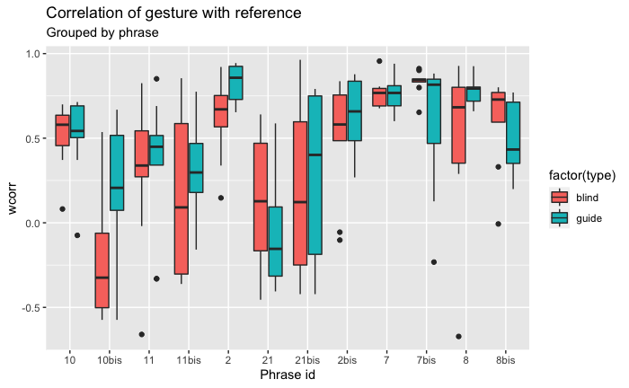

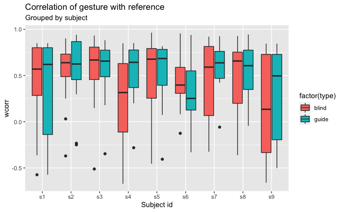

[figure not shown]

This plot shows a big problem with how we are comparing the gesture with the reference. In the reference phrase, there is no sound at the beginning and end of the recording. If we look at the intensity plot, the vocalization does not start right at 0 and end right at 1. The gesture, starts at the point where sound starts. We have been comparing the gesture with the entire duration of the reference, but we should really only be comparing it with the central part of the recording with the actual sound.

This might be why results so far have not made sense.

# A different way of comparing

Compare the gesture to only the part of the reference with the syllables.

compare2 <- function(gest_id) { # Get the first gesture from the list my_gest <- slice(gests_data, gest_id)

# Get the original data my_gest_data <- gest_originals[[gest_id]] # Find the starting and ending scrub times start_scrub <- my_gest_data$scrub[1] end_scrub <- tail(my_gest_data$scrub, 1)

# Find the corresponding phrase for this gesture my_ref <- get_ref_psgs_interp(my_gest$phrase) # Number of points in my_ref my_ref_length <- length(my_ref$f) # Get the start and index of the reference phrase based on the start and end scrub points my_ref_start_index <- floor(start_scrub * my_ref_length) my_ref_end_index <- ceiling(end_scrub * my_ref_length) # Get the part of the reference to compare with the gesture my_ref_f <- my_ref$f[my_ref_start_index:my_ref_end_index] my_ref_t <- my_ref$t[my_ref_start_index:my_ref_end_index]

# Get the intensity too my_ref_i <- get_ref_tsi(my_gest$phrase)[my_ref_start_index:my_ref_end_index]

# Now, interpolate the original gesture based on the number of points in the subset of the reference my_gest_interp<-get_interpolated_data(my_gest_data, length(my_ref_f))

return(weightedCorr(my_ref_f, my_gest_interp$f, method = , weights = my_ref_i, ML = FALSE, fast = TRUE)) }

# Run new comparison on all the gestures

gests_data <- add_column(gests_data, wcorr2 = compare2_all)

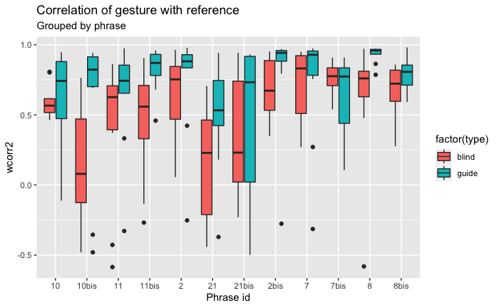

# Boxplots of wcorr by subject

[figure not shown]

```r
# Put the original and the gesture into a tibble
  comparison<-tibble(ref_f = my_ref_subset, ref_t = my_ref_subset_t, ref_i = my_refi_subset,
                   gest_f = my_gest_interp$f, gest_s = my_gest_interp$scrub)
```

[output not shown]